# My Shiny App for Machine Learning

Puneet Singla

8/18/2021

# How to use this application?

My Shiny app allows its users to pick the predictors from the IRIS dataset, build a Machine Learning model, and evaluate its accuracy in three simple steps:

1. Step 1: Select the predictors of your choice
2. Step 2: Click Submit
3. Step 3: Sit back, relax and see the Magic!!

# How does this application work?

My Shiny app uses the IRIS dataset and RPART Machine Learning algorithm from the CARET package to build classification and regression trees. The following steps are involved:

1. Step 1: Based on user selection of predictors, first create a subset of the IRIS dataset limited to selected predictors.
2. Step 2: Divide the IRIS data into Training (60%) & Test datasets (40%)
3. Step 3: Train the Machine Learning model using the training dataset & plot the results
4. Step 4: Calculate the in-sample & out-of-sample error rate
5. Step 5: Pass the calculated values from Server.R to UI.R to display on the UI

**Code Links below:** [Github: UI.R](https://github.com/PuneetSingla5822/MyShinyApp/blob/gh-pages/Assignment4/ui.R), [Github: Server.R](https://github.com/PuneetSingla5822/MyShinyApp/blob/gh-pages/Assignment4/server.R), [Github: R Markdown](https://github.com/PuneetSingla5822/MyShinyApp/blob/gh-pages/index.RMD)

# Code Demo: Server Calculation (1/2)

Let’s assume that a user only selected Petal Length to predict the Species of the flower. In the below code chunk, Server. R will create a subset of the IRIS dataset and divide it into training and test datasets.

```r
iris <- iris[,c(3,5)]     #Petal Length is at position 3 and Species is at position 5

## Create Training & Test datasets
ml_inTrain <- createDataPartition(iris$Species, p = 0.6)[[1]]
ml_train <- iris[ml_inTrain,]
ml_test <- iris[-ml_inTrain,]
dim(ml_train)
```

```
## [1] 90  2
```

```r
dim(ml_test)
```

```
## [1] 60  2
```

# Code Demo: Server Calculation (2/2)

Next, Server. R will create the Machine Learning model using the classification and regression trees method, plot the results, and calculate the in-sample and out-of-sample error rates.

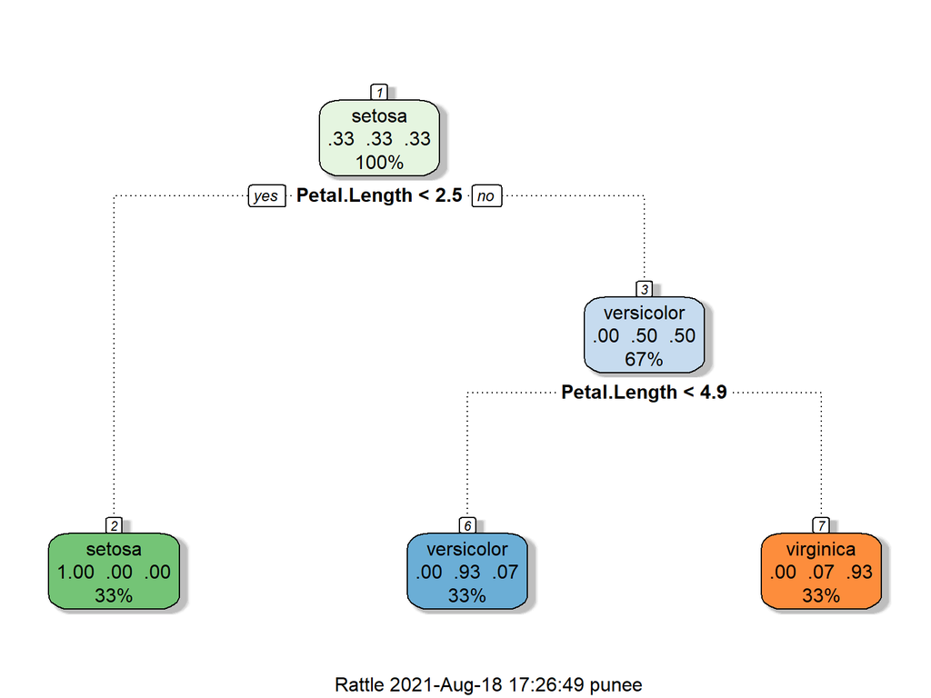

```r
## Create & Plot the model
ml_mdl <- train(Species ~ ., data = ml_train, method = "rpart")
fancyRpartPlot(ml_mdl$finalModel)
```

In-sample error rate: 4.44%

Out-of-sample error rate: 5%